# From causal diagrams to regression

GEOG 531 · Linear, logistic and Poisson models

Varun Goel

## Two classes, one modeling workflow

| Class 1 | Class 2 |
| --- | --- |
| DAG-based adjustment | Logistic interpretation |
| Linear models and diagnostics | Poisson counts and exposure |
| Lab 1, then a logistic introduction | Lab 2 in two parts |

**Our goal:** explain the comparison a model estimates.

## One simulated urban heat study

400 households, with one respondent per household.

| Outcome | What is measured? |
| --- | --- |
| Indoor temperature | Degrees Celsius |
| Respondent heat illness | Yes or no during a fixed window |
| Household heat illness episodes | A count over measured person-weeks |

The same canopy contrast appears in all three models.

## Class 1: the causal question

Does greater residential tree canopy reduce indoor heat?

| Decision | Our target |
| --- | --- |
| Unit | One household |
| Exposure | Tree canopy around the home |
| Outcome | Indoor temperature, °C |
| Contrast | 10 percentage points more canopy |
| Effect | Total effect, including shade |

## Which path needs adjustment?

[figure not shown]

Working DAG for indoor temperature.

**Discuss:** Which variable blocks a backdoor path? What happens if we add shade?

## From the DAG to the formula

| Variable | Decision for the canopy total effect |
| --- | --- |
| Deprivation | Include to block the backdoor path |
| Shade | Exclude to keep the mediated pathway open |
| Cool roof | Optional outcome predictor for precision |

```r
indoor_temp_c ~ canopy10 + deprivation + cool_roof
```

## A linear model describes a mean

The fitted line describes **average temperature** at a predictor value.

- A slope describes the change in that mean.
- A residual is observed temperature minus fitted temperature.
- Least squares chooses coefficients to minimize squared residuals.

A particular household can lie above or below its predicted mean.

## Continuous predictor: first settle the unit

```r
canopy10 = canopy_pct / 10
```

| Change | Units of `canopy10` |
| --- | --- |
| 20% to 30% canopy | +1 |
| 20% to 40% canopy | +2 |

**10 percentage points** differs from a **10% relative increase**.

## Binary predictor: a group comparison

`cool_roof`: 0 = absent, 1 = present.

| Roof group | Mean indoor temperature |
| --- | --- |
| 0: absent | 33.78°C |
| 1: present | 32.43°C |
| Difference, 1 minus 0 | −1.36°C |

A binary predictor can appear in a linear regression.

## The adjusted model in R

```r
m2 <- lm(
  indoor_temp_c ~ canopy10 + deprivation + cool_roof,
  data = d
)

coef_table(m2)
```

`~` means “modeled using.” The predictors follow it.

The helper displays coefficients and 95% intervals.

## The coefficient table

| Term | Estimate | 95% interval |
| --- | --- | --- |
| Intercept | 34.925 | 34.415 to 35.435 |
| Canopy, per 10 percentage points | −0.568 | −0.668 to −0.467 |
| Deprivation, 1 vs 0 | +2.316 | +2.023 to +2.608 |
| Cool roof, 1 vs 0 | −1.373 | −1.609 to −1.136 |

All coefficients use the outcome’s units: **°C**.

## Interpreting the canopy coefficient

At the same deprivation category and roof status,

**10 percentage points more canopy** is associated with

**0.57°C lower mean indoor temperature.**

For 20% versus 40% canopy, the fitted difference is about **−1.14°C**.

## Interpreting a binary predictor and the baseline

**Cool roof:** roof = 1 homes have a fitted mean **1.37°C lower** than roof = 0 homes, at the same canopy and deprivation.

**Intercept:** the fitted mean at canopy = 0%, deprivation = 0 and roof = 0.

Our observed canopy starts at 5%. This intercept extrapolates.

## What does “holding constant” mean?

The model compares predictions at the **same values of the other included variables**.

An additive model assumes the same canopy slope for both roof groups.

A moderator changes a comparison across groups. We represent that with an **interaction**.

## Before adjusting: predict the direction

In this study:

- Higher deprivation goes with **less canopy**.
- Higher deprivation goes with **higher temperature**.

**Discuss:** Will the crude canopy slope look more or less strongly cooling than the deprivation-adjusted slope?

## Comparing everyone and comparing within groups

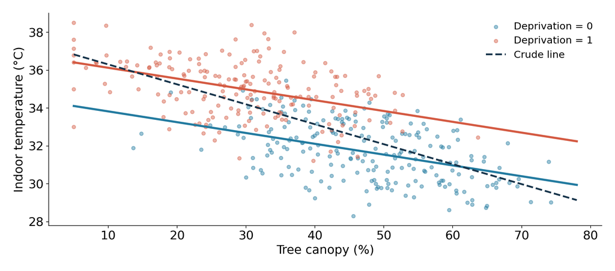

Crude and deprivation-adjusted canopy associations in simulated households.

## What changed after adjustment?

| Model | Canopy slope, °C per 10 percentage points |
| --- | --- |
| Crude | −1.053 |
| Adjust for deprivation | −0.571 |
| Also include cool roof | −0.568 |

The DAG explains why we adjust. A coefficient change alone does not establish confounding.

## Adding a mediator changes the question

| Model | Canopy slope |
| --- | --- |
| Deprivation and roof adjusted | −0.568°C |
| Also adjust for shade | −0.213°C |

Including shade blocks part of the pathway we wanted in the **total effect**.

A smaller coefficient does not show that the earlier model was wrong.

## The estimate includes sampling uncertainty

**Canopy coefficient:** −0.57°C per 10 percentage points.

**95% interval:** approximately −0.67 to −0.47°C.

- Report the estimate, interval, contrast and adjustment set.
- A small p-value does not establish causation or practical importance.
- The interval does not account for every uncertainty in the design.

## Two kinds of model checks

| The comparison | The fitted model |
| --- | --- |
| Is the adjustment set justified? | Is the conditional mean shape adequate? |
| Are comparable observations available? | Does the uncertainty calculation fit the data? |
| Could measurement or selection bias matter? | Do unusual observations dominate? |

Residual plots help assess model behavior. They cannot prove causal identification.

## What do these patterns suggest?

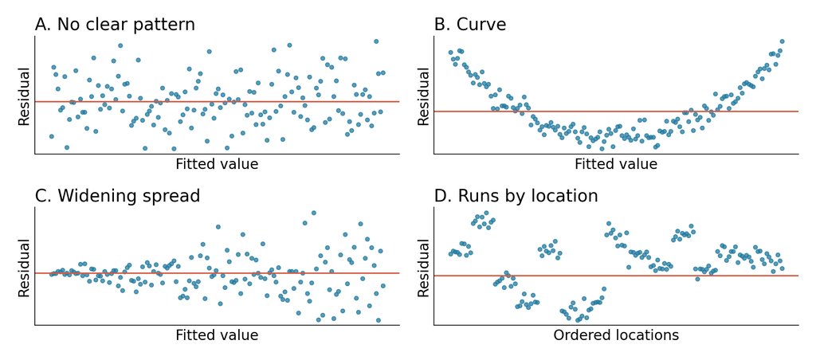

Four deliberately constructed residual patterns.

## Which response fits the problem?

| Concern | A useful next step |
| --- | --- |
| Curved residual pattern | Reconsider the mean model |
| Nonconstant error variance | Consider HC3 robust uncertainty |
| Spatial or grouped dependence | Examine location, time and grouping |
| Influential point | Check data and model sensitivity |

Normality concerns the **conditional errors** for normal-theory inference. X and Y need not themselves be normal.

## Lab 1: a DAG-based linear model

**25 minutes** · Open `02_lab_linear.qmd`.

1. Choose the adjustment set.
2. Compare crude and adjusted estimates.
3. Interpret continuous and binary predictors.
4. Inspect residuals and overlap.

One partner runs the code. The other explains. Switch after Q2.

## The outcome can change while the predictors stay

Now the outcome is **respondent heat illness**, coded 0 or 1.

A straight-line probability model can predict below 0 or above 1.

Logistic regression describes an S-shaped probability curve that stays between **0 and 1**.

The **outcome** selects the family.

## Three outcomes, three model scales

| Outcome | Model and link | Mean on the response scale |
| --- | --- | --- |
| Temperature, °C | Linear, identity | Mean temperature |
| Respondent illness, 0/1 | Binomial, logit | Probability |
| Episode count | Poisson, log | Expected count |

A GLM links the outcome’s mean to an additive predictor score.

## Our first logistic model

```r
logit_model <- glm(
  heat_illness ~ canopy10 + deprivation + cool_roof,
  family = binomial(link = "logit"), data = d
)
```

The canopy coefficient is about **−0.340 in log-odds**.

`exp(-0.340)` is about **0.712**, an **odds ratio**.

## Class 1 exit questions

1. What chooses the family: the outcome or a predictor?
2. Which variable blocks the canopy backdoor path?
3. If an odds ratio is 0.70, can we say probability is 30% lower?

Bring a short explanation to the next class.

## Class 2: same design questions, new scales

Today we will interpret **odds ratios**, calculate **probabilities**, and model **episode rates**.

For each GLM, deprivation remains a common cause of canopy and the outcome.

The shade mediator belongs to our separate temperature example.

## Probability and odds use different denominators

| If probability is… | Odds are… |
| --- | --- |
| 0.20 | 0.20 / 0.80 = 0.25 |
| 0.50 | 0.50 / 0.50 = 1.00 |
| 0.80 | 0.80 / 0.20 = 4.00 |

An odds ratio multiplies **odds**. Probability stays between 0 and 1.

## Interpreting logistic slopes

| Predictor | Odds ratio | 95% interval |
| --- | --- | --- |
| Canopy, per 10 percentage points | 0.712 | 0.573 to 0.883 |
| Cool roof, 1 vs 0 | 0.393 | 0.233 to 0.663 |

At the same deprivation and roof status, 10 percentage points more canopy is associated with **28.8% lower odds** of respondent illness.

The null odds ratio is **1**.

## Predicted probabilities give a familiar scale

For deprivation = 0 and cool roof = 0:

| Canopy | Predicted illness probability |
| --- | --- |
| 20% | 30.8% |
| 40% | 18.4% |

**Difference: −12.4 percentage points.**

These are point predictions for two specified profiles.

## Predicting in R

```r
homes <- data.frame(
  canopy10 = c(2, 4),
  deprivation = 0, cool_roof = 0
)

predict(logit_model, newdata = homes,
        type = "response")
```

`type = "response"` returns probabilities for a logistic model.

## A constant OR can mean changing probability differences

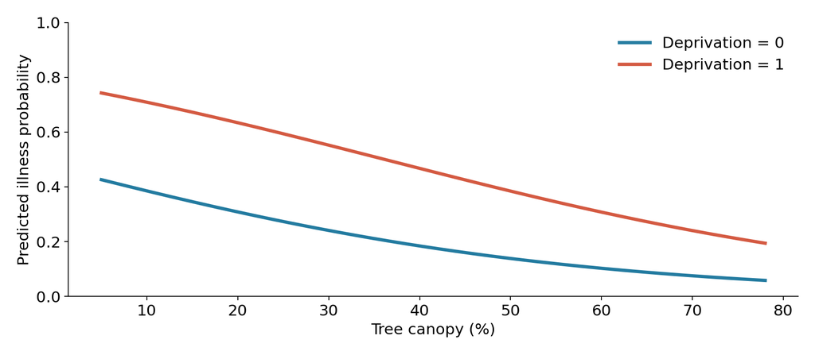

Fitted illness probabilities at two deprivation categories, holding cool roof at 0.

## Lab 2A: odds and probabilities

**15 minutes** · Open Part A of `03_lab_glm.qmd`.

1. Confirm what 0 and 1 mean.
2. Interpret an OR and its interval.
3. Predict two illness probabilities.
4. Read the calibration table and convergence result.

Return with an **odds statement** and a **probability statement**.

## Counts depend on observation opportunity

| Household | Episodes | Person-weeks | Episodes per 100 person-weeks |
| --- | --- | --- | --- |
| A | 4 | 100 | 4 |
| B | 2 | 20 | 10 |

A has more episodes. B has the higher observed rate.

**Person-weeks = people × weeks observed.**

## Poisson regression and an exposure offset

Poisson regression models a **nonnegative integer count**.

Its log link makes expected counts positive.

```r
offset(log(person_weeks))
```

The offset coefficient is fixed at **1**. At the same predictor values, twice the exposure implies twice the expected count.

## The count model in R

```r
count_model <- glm(
  heat_episodes ~ canopy10 + deprivation + cool_roof +
    offset(log(person_weeks)),
  family = poisson(link = "log"), data = d
)

coef_table(count_model, exponentiate = TRUE)
```

Keep the **count** on the left. Supply exposure through the offset.

## Interpreting incidence rate ratios

| Predictor | Rate ratio | 95% interval |
| --- | --- | --- |
| Canopy, per 10 percentage points | 0.754 | 0.688 to 0.827 |
| Cool roof, 1 vs 0 | 0.655 | 0.518 to 0.828 |

At the same deprivation and roof status, 10 percentage points more canopy is associated with a **24.6% lower episode rate**.

The null rate ratio is **1**.

## Expected counts at a specified exposure

For deprivation = 0 and cool roof = 0:

| Canopy | At 100 person-weeks | At 200 person-weeks |
| --- | --- | --- |
| 20% | 2.78 episodes | 5.56 episodes |
| 40% | 1.58 episodes | 3.16 episodes |

Counts double when exposure doubles. The predicted **rates** stay the same.

An expected count can be fractional.

## Lab 2B: counts, rates and dispersion

**15 minutes** · Continue Part B of `03_lab_glm.qmd`.

1. Identify the count and exposure.
2. Fit the Poisson model with an offset.
3. Interpret an IRR and predict counts.
4. Compare conditional dispersion in two outcomes.

Switch driver and interpreter roles.

## Logistic diagnostics ask different questions

| Check | Why it matters |
| --- | --- |
| 0/1 coding | The model predicts P(Y = 1) |
| Warnings or extreme coefficients | Possible separation or instability |
| Observed vs fitted probabilities | Possible mean-model mismatch |
| Continuous-predictor shape | Additivity is on the log-odds scale |

Binary residuals do not need to look normally distributed.

## Poisson variation is conditional

The Poisson model sets variance equal to the mean **given the predictors and exposure**.

| Outcome | Pearson dispersion ratio |
| --- | --- |
| Main episode count | 0.97 |
| Deliberately more variable count | 1.79 |

A value well above 1 prompts investigation of extra conditional variation.

## The same contrast on three scales

For 10 percentage points more canopy, at the stated other predictor values:

| Model | Reported comparison | Null |
| --- | --- | --- |
| Linear | −0.57°C mean difference | 0 |
| Logistic | 0.71 odds ratio | 1 |
| Poisson with offset | 0.75 episode rate ratio | 1 |

The family changes the scale. The causal question still needs a justified design.

## Exit ticket and the next modeling question

1. Choose a family for temperature, any respondent illness and episode count.
2. Explain the difference between −0.57°C, OR = 0.71 and IRR = 0.75.
3. What if residuals cluster among neighbors, or households repeat within neighborhoods?

Next week: **spatial dependence and hierarchical structure**.

## Optional reference: moderators and interactions

```r
lm(indoor_temp_c ~ canopy10 * cool_roof + deprivation,
   data = d)
```

| Quantity | Interpretation |
| --- | --- |
| `canopy10` | Canopy slope for roof = 0 |
| `canopy10:cool_roof` | Difference in canopy slope for roof = 1 |
| Sum of the two | Canopy slope for roof = 1 |

## Optional reference: robust uncertainty

```r
coef_table(m2)
coef_table(m2, robust = TRUE)  # HC3
```

The fitted OLS coefficients stay the same. Standard errors and intervals can change.

HC3 addresses heteroskedastic inference under suitable independence assumptions. It does not repair the causal design or the mean model.

## Optional reference: outcome-family checks

| Model | Outcome and main statistical checks |
| --- | --- |
| Linear | Conditional mean form, variance, influence, residual tails |
| Logistic | Binary coding, log-odds mean form, separation, calibration |
| Poisson | Integer count, log-mean form, positive exposure, dispersion |

For all: adjustment, overlap, measurement, selection and independence.

## Assigned readings

- [The Effect, Chapter 13: Regression](https://theeffectbook.net/ch-StatisticalAdjustment.html)
- [OpenIntro, Chapter 24: Single-predictor linear inference](https://openintro-ims.netlify.app/inf-model-slr)
- [OpenIntro, Chapter 25: Multiple-predictor linear inference](https://openintro-ims.netlify.app/inf-model-mlr)
- [OpenIntro, Chapter 26: Logistic inference](https://openintro-ims.netlify.app/inf-model-logistic)

Poisson counts and exposure offsets extend these assigned chapters.

## Model documentation and teaching files

- Official R documentation: [`glm`](https://stat.ethz.ch/R-manual/R-devel/library/stats/html/glm.html), [families](https://stat.ethz.ch/R-manual/R-devel/library/stats/html/family.html), [offsets](https://stat.ethz.ch/R-manual/R-devel/library/stats/html/offset.html)
- Lab 1: `02_lab_linear.qmd`
- Lab 2: `03_lab_glm.qmd`
- Expanded lecture notes: `01_lecture_notes.html`

All study records are simulated. Predictions shown are point predictions unless an interval is stated.